# Projekt 2.0

Michał Baran

20 maja 2019

### Wprowadzenie

Celem projektu jest stworzenie funkcji symulującej próbki z rozkładów mieszanych oraz analiza mocy testów zgodności oraz rangowych dla próbek otrzymanych w ten sposób. Analiza będzie polegać na stworzeniu ramek danych uwzględniających moce testów w zależności od:  
* Długości próby.  
* Prawdopodobieństwa wylosowania liczby z pierwszego rozkładu.  
* Parametrów poszczególnych rozkładów.

Do wykonania projektu posłużę się trzema testami:

- **Jarque Bera**  
  Test ten jest najczęściej uzywanym testem w ekonometrii.Powodem tego jest jego prostota oraz znana nieskomplikowana postać rozkładu asymptotycznego. Konstrukcja statystyki testowej bazuje na wartościach momentów rozkłądu zmiennej losowej obliczonych na podstawie próby empiryczniej i porównaniu ich z momentami teoretycznumi rozkładu normalnego. Test weryfikuje hipotezę o jednowymiarowej normalności zmiennej losowej przeciwko innemu dowolnemu rozkładowi.
- **Shapiro-Wilka**  
  Test ten jest uznawany za najlepszy do sprawdzania normalności rozkładu zmiennej losowej, ponieważ charakteryzuje go duża moc, czyli duże prawdopodobieństwo odrzucenia hipotezy zerowej jeśli jest ona fałszywa. Polecany jest dla małych próbek, ponieważ gdy liczba obserwacji przekracza 2000 może zwracać blędne wyniki. Test weryfikuje hipotezę mówiącą o o tym, że rozkład naszej zmiennej jest zbliżony do normalnego.
- **Wilcoxona**  
  Jest nieparametryczną alternatywą dla testu t-Studenta dla przypadku dwóch równolicznych próbek dających sis połączyć w pary. Często używa się tego testu do porównywania danych zebranych przed i po eksperymencie, w celu zbadania, czy nastąpiła istotna statystycznie zmiana.

Dane którymi będę się posługiwał przedstawię w postaci wektorów.

1. *p* - prawdopodobieństwo wylosowania liczby z pierwszego rozkładu
2. *n* - długości próby
3. *par1* - parametry pierwszego rozkładu
4. *par2* - parametry drugiego rozkładu

### Zadanie 1

Podstawą całego projektu będzie stworzenie funkcji **rmix**, która pozwoli mi na symulowanie próbek z rozkładów mieszanych. Jej parametrami będą:  
– **n** - długość próby  
– **family_1** - pierwszy typ rozkładu  
– **par_1** - parametry pierwszego rozkładu  
– **family_2** - drugi typ rozkładu  
– **par_2** - parametry drugiego rozkładu  
– **p** - prawdopodobieństwo, że liczba pochodzi z pierwszego rozkładu

Funkcja w oparciu o wektor **prob**, który jest wektorem posiadającym jedynie liczby *1* oraz *2* bada ile należy wylosować liczb z każdego z rozkładów. Następnie tworzy dwie próbki, które są wartościami pochodzącymi z wybranych przez nas rozkladów. Na końcu funkcja zwraca wektor, który jest połaczeniem obu tych próbek.

```r
rmix <- function(n,family_1,par_1,family_2,par_2,p){

  prob <- sample(c(1,2), n, prob = c(p, 1-p), replace = T)

  sample1 <- eval(
    parse( text =
             paste0("r", family_1, "(length(which(prob == 1)), ",
                    paste(par_1, collapse = ", "),
                    ")"))
  )
  sample2 <- eval(
    parse( text =
             paste0("r", family_2, "(length(which(prob == 2)), ",
                    paste(par_2, collapse = ","),
                    ")"))
  )
  c(sample1,sample2)
}
```

### Zadanie 2

Dzięki pomocy funkcji **rmix** przeanalizuje moce testów zgodności dla mieszanki dwóch rozkładów normalnych przy hipotezie zerowej o rozkładzie normalnym.

Najpierw zbadam czy zmiana wartości *n* oraz *p* istotnie wpływa na zmianę mocy testu.  
Poniższa analiza powinna sprawdzić czy poniższe hipotezy są prawdziwe:

*Długość próby*  
H0: Wzrost długości próby powoduje wzrost mocy testu  
H1: Wzrost długości próby powoduje spadek mocy testu

*Poziom prawdopodobieństwa wystąpienia zmiennych z pierwszego rozkładu*  
H0: Wzrost prawdopodobieństwa powoduje wzrost mocy testu  
H1: Wzrost prawdopodobieństwa powoduje spadek mocy testu

Oczekiwanym rezultatem jest brak podstaw do odrzucenia hipotezy zerowej.

Wprowadzam wartości poszczególnych zmiennych:

```r
#długość
n <- c(10,50,100,200)
#prawdopodobieństwo
p <- c(0.1,0.3,0.5,0.9)
#par_1
par1 <- c(5,4)
#par_2
par2 <- c(10,5)
#ilość symulacji
N <- 100
#alpha, która pozwala na badanie mocy testów
alpha <- 0.1
#testy - skrótowe nazy testów którymi posługuję się w projekcie
testy <- c("SW","JB")
```

Tworzę ramke danych:

```r
data1 <- expand.grid(n,p,testy)
colnames(data1) <- c("Dlugosc", "Prawdopodobienstwo","Test")
```

Dla każdej kombinacji z *data1* badam moc testów i zapisuje do wektora *powers*, który następnie dopisuje do ramki danych.

```r
set.seed(20)

powers <- sapply(1:nrow(data1),
                 function(i){
                   n <- data1[i, 1]
                   p <- data1[i, 2]
                   test <- data1[i, 3]

                   p_vector <- sapply(rep(n, N), function(x){
                     sample <- rmix(n, "norm", par1, "norm", par2, p)

                     if (test == "SW"){
                       result <- shapiro.test(sample)$p.value
                     } else if (test == "JB"){
                       result <- jarque.bera.test(sample)$p.value
                     }
                     result
                   })
                   mean(p_vector < alpha)
                 })

data2 <- bind_cols(data1, Moc = powers)
```

Tworzę wykres przedstawiający jak zmienia się moc testów w zależności od *n* i *p*:

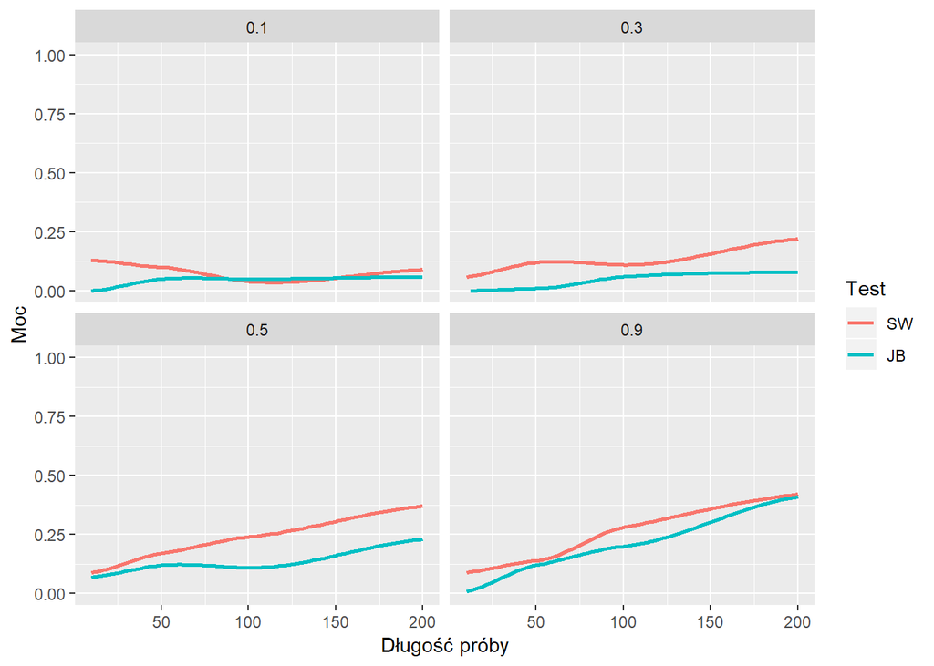

Następnym punktem, będzie zbadanie jak zmiana parametrów pierwszego rozkładu wpłynie na moc testów. Aby to uczynić, tworzę nową ramkę danych dzięki której będę w stanie zmieniać pierwszy i drugi parametr w *par_1*.

```r
#długość
n <- c(10,50,100,200)
#prawdopodobieństwo
p <- 0.6
#par_2
par2 <- c(6,2)
#dane do zmiany
zmiana <- seq(2,10, by = .25)


data3 <- expand.grid(Dlugosc = n, Prawdo = p, Zmiana = zmiana, Test = testy)
```

Przy wykorzystaniu tej samej metodyki co wcześniej, wykonuję badanie mocy testów oraz wizualiazcję.

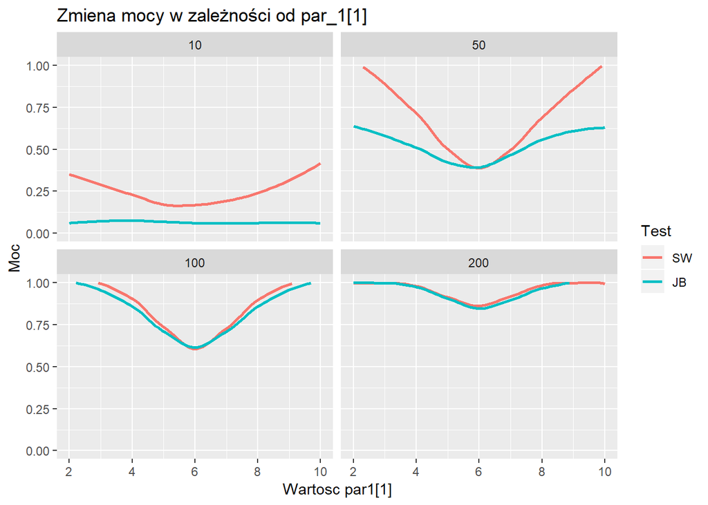

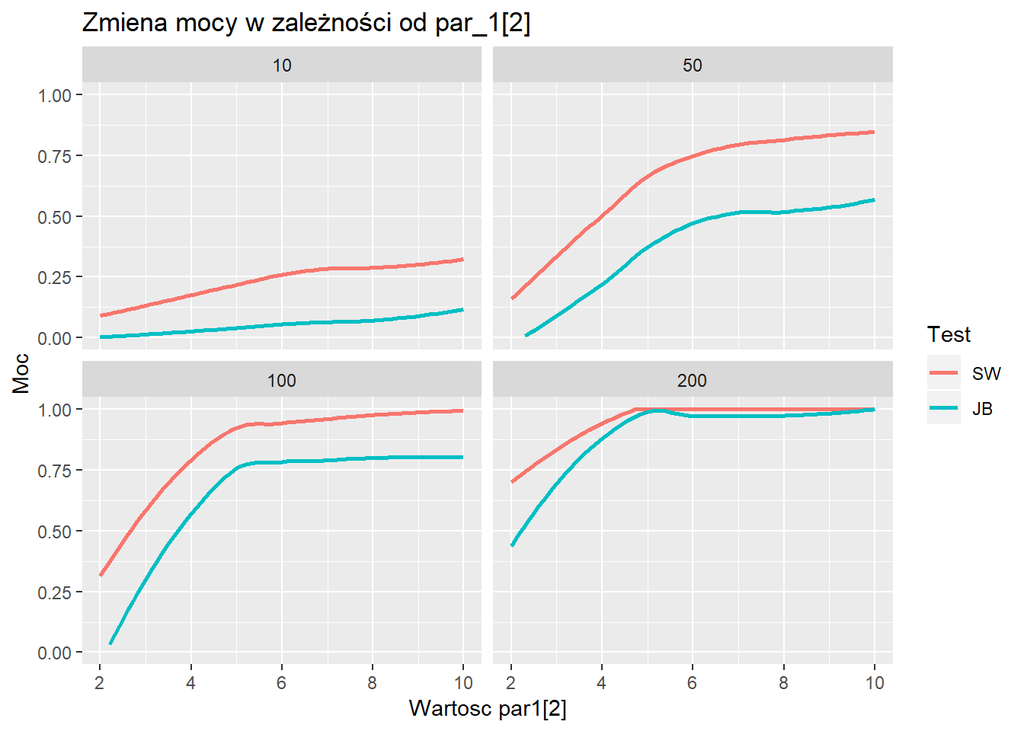

Jak widać na powyższych grafikach, moc testów maleje tylko w miejscu, gdzie parametry badanego przez nas rozkładu zbliżają się do wartości parametrów rozkładu drugiego. Spowodowane jest to faktem, że badane przez nas rozkłady w takiej syuacji nie różnią się od siebie znacząco.

Ostatnim punktem będzie sprawdzenie czy zmiana parametrów drugiego rozkładu wpłynie istotnie na zmianę mocy testów. Postępnowanie, które wykonam będzie identyczne jak w punkcie powyżej.

Oto otrzymane wyniki:

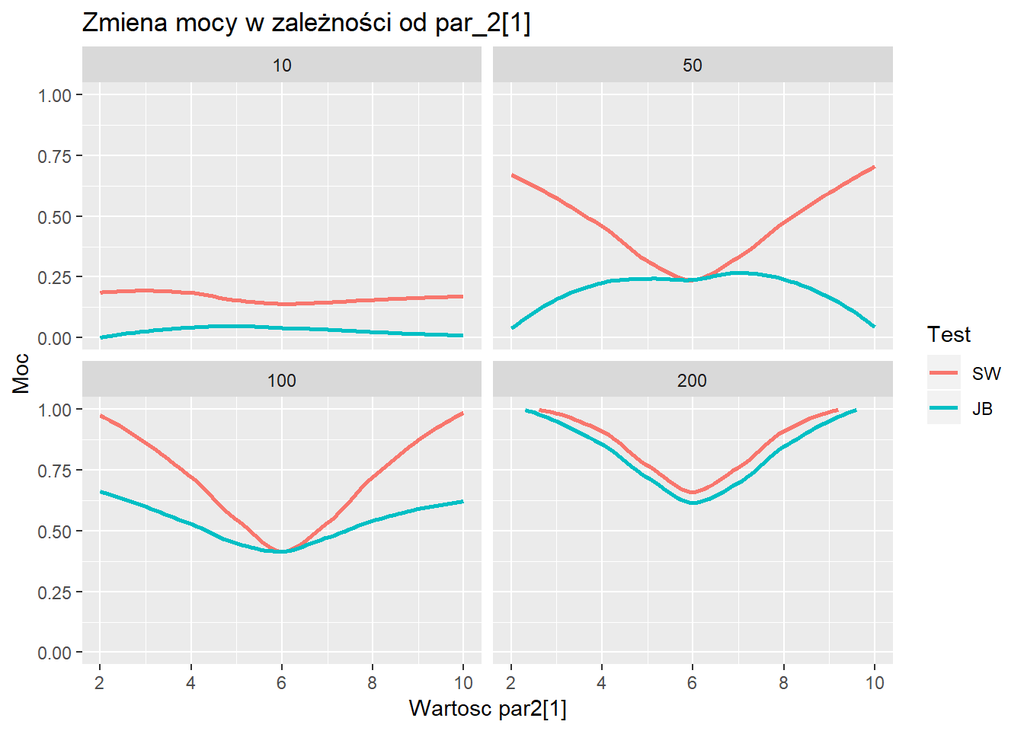

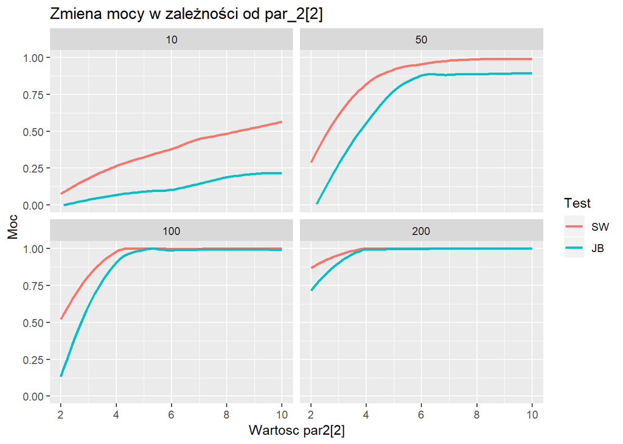

Grafiki pokazują, że moc testów zachowuje się prawie identycznie jak w momencie zmiany parametrów pierwszego rozkładu - gdy wartość parametrów zbliża się do wartości z rozkładu pierwszego moc maleje.

### Zadanie 3

Dzięki pomocy funkcji **rmix** przeanalizuje moc testu Wilcoxona dla mieszanki rozkładów Poissona przy hipotezie zerowej o rozkładzie Poissona. W analizie sprawdzę jak zmiana *n*, *p* oraz *par_2* wpłynie na moc. *par_1* przez cały czas zostanie niezmienione.

Wprowadzam wartości zmiennych i tworzę pomocniczą ramkę danych:

```r
#długość
n <- c(50,100,200)
#prawdopodobieństwo
p <- c(0.3,0.5,0.9)
#par_1
par1 <- c(10)
#par_2
par2 <- c(1:25)
#ilość symulacji
N <- 100
#alpha, która pozwala na badanie mocy testów
alpha <- 0.5

data1 <- expand.grid(Par2 = par2, Dlugosc = n, Prawdo = p)
```

Przy pomocy pętli **for** tworze wektor *powers* w którym zbieram moce testu dla każdego zestawienia zmiennych, a następnie dopisuje go do ramki danych:

```r
set.seed(20)
for (i in 1:nrow(data1)) {
  n <- data1[i, 2]
  par2 <- data1[i, 1]
  p <- data1[i, 3]
  for (j in 1:N) {
    sample <- rmix(n, "pois", par1, "pois", par2, p)
    sampleP <- rpois(n, par1)
    p_vector[j] <- wilcox.test(sample, sampleP, paired = T)$p.value
  }
  powers1[i] <- mean(p_vector < alpha)
}
```

```r
data2 <- bind_cols(data1, Moc = powers1)
```

W oparciu o wcześniej stworzoną ramkę tworzę wykres przedstawiający zmianę mocu testu:

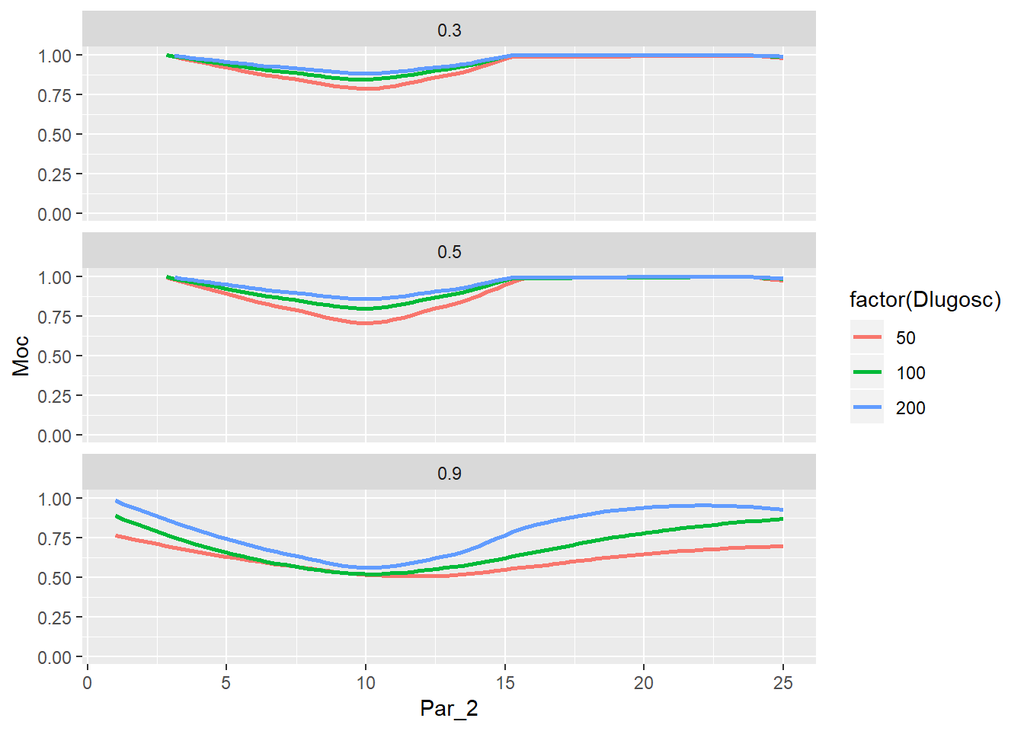

Z powyższej grafiki możemy wywnioskować, że wraz ze wzrostem długości próby, rośnie moc testu. Odwrotną sytuację możemy zaobserwować przy zwiększaniu prawdopodobieństwa wylosowania liczby z pierwszego rozkładu - wtedy moc testu maleje. Natomiast przy zmianie *par2* widzimy, że moc testu spada gdy wartość tego parametru jest w pobliżu wartości *par1*. Dzieje się tak, ponieważ w tym miejscu próbka mieszana jest prawie taka sama jak ta, z którą ją porównujemy.